# Time Series Homework: Chapter 1 Lesson 3 Key

### Question 2 - Seasonal Averages: Side-by-Side Box Plots by Month (10 points)

Please create a box plot to illustrate the monthly averages in the US Unemployment time series. Use the appropriate axis labels, units, and captions.

**NoteAnswer**

**GGPlot**

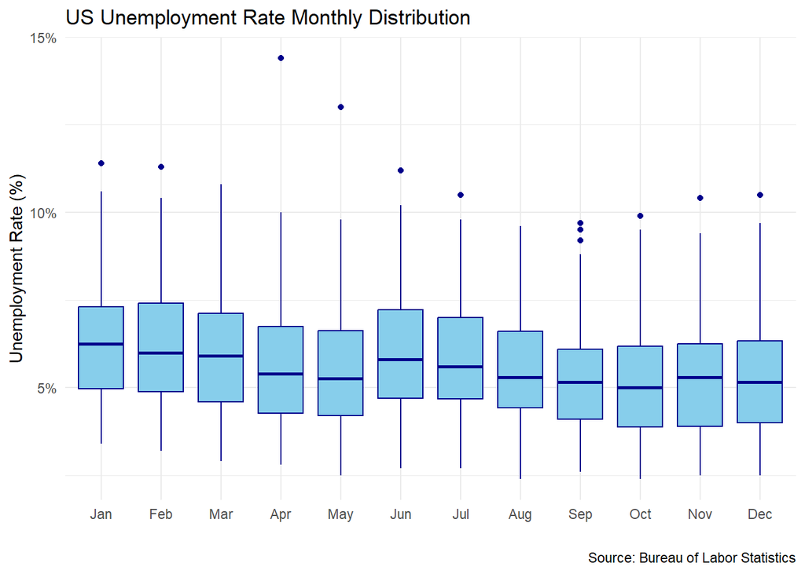

```r
unemp_rate <- unemp_rate |>
  mutate(
    month = factor(month(date, label = TRUE), levels = month.abb)
  )

ggplot(unemp_rate, aes(month, value)) +
  geom_boxplot(fill = "skyblue", color = "darkblue") +
  scale_y_continuous(labels = scales::percent_format(scale = 1)) +
  labs(
    title = "US Unemployment Rate Monthly Distribution",
    x = "",
    y = "Unemployment Rate (%)",
    caption = "Source: Bureau of Labor Statistics"
  ) +
  theme_minimal()
```

**Plotly**

```r
pacman::p_load(plotly)

mydata2 <- unemp_rate |>
  mutate(month = factor(month)) |>
  group_by(month) |>
  mutate(
    iqr_val = IQR(value, na.rm = TRUE),
    lower_bound = quantile(value, 1 / 3, na.rm = TRUE) - 1.5 * iqr_val,
    upper_bound = quantile(value, 2 / 3, na.rm = TRUE) + 1.5 * iqr_val,
    is_outlier = value < lower_bound | value > upper_bound
  ) |>
  ungroup()

# Reverted to filtering the base plot data to prevent Plotly from drawing default outliers
p <- ggplot(filter(mydata2, !is_outlier), aes(x = month, y = value)) +
  geom_boxplot(outlier.shape = NA) +
  geom_point(
    data = filter(mydata2, is_outlier),
    aes(text = paste("Year:", year(date), "<br>Rate:", value)),
    color = "#E69F00",
    size = 1
  ) +
  labs(x = "Month", y = "Unemployment Rate (%)", title = "Monthly Unemployment Rate Distribution") +
  scale_x_discrete(labels = month.abb) +
  scale_y_continuous(labels = scales::percent_format(scale = 1)) +
  theme_bw() +
  theme(plot.title = element_text(hjust = 0.5))

ggplotly(p, tooltip = "text") |> config(displayModeBar = FALSE)
```

[interactive chart not shown]

### Question 3 - Seasonal Averages: Analysis (20 points)

##### a) Describe the seasonality of the US unemployment time series. Comment on the series’ periods of highest and lowest unemployment. Are there any notable outliers?

**NoteAnswer**

Here in the box plot we can see that the highest median unemployment rates are typically around the beginning of the year from January to Februrary, then later in the year, June and July have higher unemployment rates once again. The periods with the lowest unemployment range from April and May, as well as September and October. The unemployment values here can be due to seasonal employment patterns. One noticiable outlier here is found in the month of April. In April 2020, the highest unemployment rate was ever recorded due to the COVID pandemic. However, there doesn’t seem to be a month that has a significantly higher unemployment rate than the other.

##### b) Please explain the patterns you found. Include information from your prior research on the series.

**NoteAnswer**

Perhaps one reason as to why there are increases in unemployment rates at the beginning of the year industries experience significant employment fluctuations due to lay offs holiday season demand in retail for workers.

Another clear example is a wave of new job seekers enters the market around this time as recent high school and college graduates begin looking for work. Since it can take some time for these individuals to secure employment, it temporarily drives up unemployment rates. Additionally, there is rise in unemployment before switching to summer months, largely due to shifts in industries like agriculture and tourism, where jobs often peak or wind down, leading to employment changes.

### Rubric

[output not shown]